# Project Python Foundations: FoodHub Data Analysis

### **Question 16:** The company wants to analyze the delivery time of the orders on weekdays and weekends. How does the mean delivery time vary during weekdays and weekends? [2 marks]

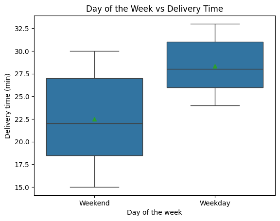

```python
plt.xlabel("Day of the week")
plt.ylabel("Delivery time (min)")
plt.title("Day of the Week vs Delivery Time")
sns.boxplot(x='day_of_the_week',y='delivery_time',data=data,showmeans = True)
plt.show();
```

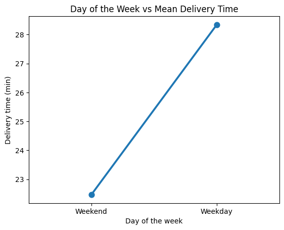

```python
plt.xlabel("Day of the week")
plt.ylabel("Delivery time (min)")
plt.title("Day of the Week vs Mean Delivery Time")
sns.pointplot(data = data,y = 'delivery_time',x = 'day_of_the_week',errorbar=None);
```

```python
df = data.groupby(['day_of_the_week'])['delivery_time'].mean()
df
```

| day_of_the_week | delivery_time |
| --- | --- |
| Weekday | 28.340 |
| Weekend | 22.470 |

**dtype:** float64

### Observations:

Delivery time is more during weekdays compared to weekend

Mean Delivery time on weekday is 28.3

Mean delivery time on weekend is 22.47

### Conclusion and Recommendations

### **Question 17:** What are your conclusions from the analysis? What recommendations would you like to share to help improve the business? (You can use cuisine type and feedback ratings to drive your business recommendations.) [6 marks]

### Conclusions:

- On analysing the total no of orders per restaurants we find some of the restaurants are really popular while some of them are least preferred
- American cuisine is the most ordered cuisine followed by Japanese and Italian
- Restaurants offering American cuisine is the highest(41),followed by Italian(31) and Japanese(29)
- American,Japanese,Chinese and Italian has lower median cost and tight range(ie not much variation in the pricing consistently) with no outliers,making them most affordable and predictable cuisine
- About 71.2% of total orders placed are during the weekends.ie majority of the orders are placed during weekends
- Mean delivery time is higher during the weekdays comapred to weekends
- Lower the cost of the order,higher the number of orders placed.
- On analysing the ratings given by the customers it shows that the customers are mostly satisfied.But about 38% of the orders are 'not given' any ratings.So we cannot be sure that the average ratings would be this high if all the orders were rated
- We can also see that majority of the orders are placed with IDS in the lower range.The number of orders placed decreases when the range of IDs increase.If the ids are sequential IDs,it shows that majority of the orders are placed by the customers who joined the app earlier

### Recommendations:

- For restaurants with lower order number it would be better to check if they are new additions,if they have limited availability or some other reason for lower interest
- Delivery_time is greater during weekdays compared to weekends.It would be better to check what is the reason behind the delay in the delivery.
- Steps should be taken to improve the delivery time as a whole especially on weekdays.Delivery time can be improved by employing more people and proper transportation for delivery
- Higher delivery time may be a reason for the lower number of orders on weekdays as the working population will be time constricted during the working hours.Longer delivery time is not feasible for the working population
- It is seen that most of the orders are placed by the members who joined the app in the earlier stages.Some kind of bonus or reward points would encourage them to place more orders
- Also some kind of joining offer must be provided for the new customers,which would encourage more customer to join and use the app
- Referral Bonus will be a good incentive which would benefit both the existing customer and new customers.Referral bonus can be in the form of

  ```
  *   Percentage  Discount on  order
  *   Free delivery on next purchase
  ```

- Reward points and cashback is another way to encourage the customers to keep using the app
- Spanish,Thai and Indian cuisines are highly rated,but the number of restaurants offering these cuisines are less.More number of restaurants that provides these cuisines ,with affordable cost and may turn beneficial
- The app can impose a small amount of revenue from the restaurants base on the cost of the order placed.A part of this revenue collected should be utilized for offers,bonus for the customers so that they are more encouraged to use the app
- Improving the food preparation time and delivery time can help in improving the rating
- Increase in the cost of the order results in lesser number of orders.To encourage customers to place orders with high cost provide them with extra benefits like free delivery if the total cost exceeds a 20.This has two advantages.One is higher cost order means higher margin and also on top of that app can impose the restaurants additional revenue if the cost exceeds a particular 20